# Escape from Boxland

A library of common geometric shapes can be used to train our brains for understanding data structure in high-dimensional Euclidean space. This article describes the methods for producing cubes, spheres, simplexes, and tori in multiple dimensions. It also describes new ways to define and generate high-dimensional tori. The algorithms are described, critical code chunks are given, and a large collection of generated data are provided. These are available in the R package *geozoo*, and selected movies and images, are available on the GeoZoo web site (http://schloerke.github.io/geozoo/).

Barret Schloerke (Department of Statistics, Purdue University) , Hadley Wickham (

RStudio Inc

) , Dianne Cook (Department of Econometrics and Business Statistics, Monash University) , Heike Hofmann (Department of Statistics, Iowa State University)  
2016-11-21

## 1 Introduction

This paper describes how to build a library of high-dimensional geometric shapes: cubes, spheres, simplexes, and tori. Data describing numerous 4D polytopes and polyhedra generated by other researchers are included in the library, a single location to describe the many different object structures. The purpose is to enable people to train their brains for understanding data structures residing in high-dimensional Euclidean space. This work extends the work described in (Cook 1997) which concentrated on samples from statistical distributions.

The [*geozoo*](https://CRAN.R-project.org/package=geozoo) package in R contains the code to create the geometric shapes. Code fragments, describing the key components of the algorithms for generating the shapes, are included in this paper. The shapes in the library are best viewed using the dynamic graphical method called a tour (Asimov 1985; Buja et al. 2005; Cook, E. K. Lee, A. Buja, and H. Wickham 2007), such as that available in GGobi (Swayne et al. 2003) and the [*tourr*](https://CRAN.R-project.org/package=tourr) R package (Wickham et al. 2011).

The structure of the paper is that basic shapes are described first followed by more complex shapes, in this order, cubes, spheres, simplexes, polyhedra, polytopes, and tori.

## 2 Cubes

Cubes are the first shape that a person should examine when starting to learn about higher dimensions. Cubes are relatively simple to understand: they have orthogonal, uniform length sides and are convex shapes. A 0-D cube is a single point. A 1-D cube is a line segment. A 2-D cube is a square and a 3-D cube is a box.

The 4-D cube may be hard to imagine, partly because we are accustomed to describing our physical world using only three dimensions. The leap to 4-D is more understandable after watching the movie “Flatland” (Martin 1965) or reading the novella of the same name (Abbott 1884). In “Flatland”, the world is 2-D and characters struggle with the concept of 3-D.

Working from this name, we might think of our world as “Boxland”: we live in 3-D and struggle with the concept of higher dimensions. Shadows created by light sources help perceive the third dimension. In Flatland, the inhabitants see only 1-D line segments. For a Flatlander who has never seen the world we live in, the third dimension is hard to understand. Similarly, for inhabitants of our world, it might seem daunting to imagine the fourth dimension. But it’s not that difficult!

Figure 1 shows the evolution of the cube from 2-D to 5-D. Each figure is a 2-D projection of a wireframe cube from two to five dimensions. To increase the dimension of a cube, replicate and shift a cube of one dimension lower along a new orthogonal axis, connecting the corresponding vertices. The 3-D cube grows from 2$\times$2-D squares, connected with four new edges. The 4-D cube is born from 2$\times$3-D cubes and a 5-D cube emerges from 2$\times$4-D cubes. Any object with more than 2 dimensions has infinitly many projections onto a 2-D plane. The projections chosen in Figure 1 (and the remaining figures of the paper) were done to highlight the overall structure or features that make each object distinct from each other.

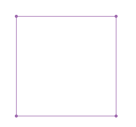

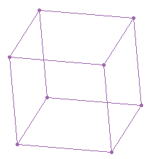

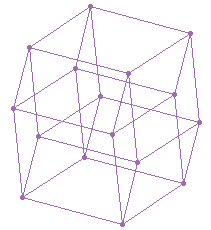

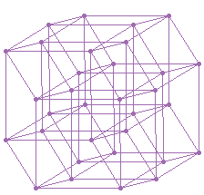

Figure 1: Wireframe cubes, (from left to right) 2-D, 3-D, 4-D, 5-D.

### 2.1 Points on vertices

The two different ways to define a high-dimensional cubes leads to two different methods to create a $p$-D cube. Both methods yield the same result, which is shown for $p=1,2,3$ in Table 1.

1-D:

Table 1: 1-D, 2-D and 3-D cube vertices and edges.

| row # | 1 | edges |
| --- | --- | --- |
| 1 | 0 | 2 |
| 2 | 1 |  |

2-D:

| row # | 1 | 2 | edges |  |
| --- | --- | --- | --- | --- |
| 1 | 0 | 0 | 2 | 3 |
| 2 | 1 | 0 |  | 4 |
| 3 | 0 | 1 | 4 |  |
| 4 | 1 | 1 |  |  |

3-D:

| row # | 1 | 2 | 3 | edges |  |  |
| --- | --- | --- | --- | --- | --- | --- |
| 1 | 0 | 0 | 0 | 2 | 3 | 5 |
| 2 | 1 | 0 | 0 |  | 4 | 6 |
| 3 | 0 | 1 | 0 | 4 |  | 7 |
| 4 | 1 | 1 | 0 |  |  | 8 |
| 5 | 0 | 0 | 1 | 6 | 7 |  |
| 6 | 1 | 0 | 1 |  | 8 |  |
| 7 | 0 | 1 | 1 | 8 |  |  |
| 8 | 1 | 1 | 1 |  |  |  |

- **Method 1:** Recursively double a lower-dimensional cube.

  Using the standard coordinate system, the base is 0 and 1. After establishing the base, we recursively double the base in the first column(s), and add an additional column containing a 0 in the first half of the rows and a 1 in the second half of the rows. The process is repeated $(p-1)$ times, to obtain a $p-$D cube.

  ```r
  cube_iterate <- function(p) {
    if (p == 1) {
      return(rbind(0, 1))
    }
    lower_dim_cube <- cube_iterate(p - 1)
    rbind(
      cbind(lower_dim_cube, 0),
      cbind(lower_dim_cube, 1)
    )
  }
  ```

- **Method 2:** Generate all permutations of ${0, 1}$ in $p$ columns.

  This method takes advantage of an existing function in R, `expand.grid`. It produces all permutations by generating the Cartesian product of a set of vectors. For our purposes, the number of columns is not fixed, so we use `do.call`, to convert a function call of the form `x(a, b, c)` to `do.call(x, list(a, b, c))`, allowing specification of an arbitrary number of arguments.

  ```r
  cube_permute <- function(p) {
    as.matrix(
      do.call(
        expand.grid,
        rep(list(c(0, 1)), p)
      )
    )
  }
  ```

### 2.2 Completing the wire frame

The wire frame for a cube draws the edges of the cube, connecting all points that differ in one of the values, e.g. $(0,0,0)$ and $(1,0,0)$, or $(0,0,0)$ and $(0,1,0)$ for a 3-D cube. Each edge is a vector of length $1$ and is defined by specifying the row numbers of the two corresponding elements of the vertex data, e.g. in a 3-D cube $(2,4)$ would connect rows $(1,0,0)$ and $(1,1,0)$. Table 1 gives vertex and edge lists for $p = 1$, $2$, and $3$. Edges are not ordered $(1,2)=(2,1)$, and we use just one of the two, with the smaller number first. Presented below are three ways to generate an edge set, the last being the most computationally efficient but less intuitive.

- **Method 1:** Distance of 1.

  ```r
  cube_edges_length1 <- function(cube) {
    p <- ncol(cube)
    num_points <- 2 ^ p
    from_to <- matrix(NA, nrow = num_points * p / 2, ncol = 2)
    next_store_position <- 1
    for (i in 1:(num_points - 1)) {
      for (j in (i + 1):num_points) {
        d1 <- sum((cube[i, ] - cube[j, ]) ^ 2)
        if (d1 == 1) {
          from_to[next_store_position, ] <- c(i,j)
          next_store_position <- next_store_position + 1
        }
      }
    }
    from_to
  }
  ```

- **Method 2:** The binomial approach.

  ```r
  cube_edges_binomial <- function(cube) {
    p <- ncol(cube)
    num_points <- 2 ^ p
    from_to <- matrix(NA, nrow = num_points * p / 2, ncol = 2)
    next_store_position <- 1
    for (i in 1:(num_points - 1)) {
      for (j in 1:p) {
        if (cube[i, j] == 0) {
          from_to[next_store_position, ] <- c(i, 2 ^ (j - 1) + i)
          next_store_position <- next_store_position + 1
        }
      }
    }
    from_to
  }
  ```

- **Method 3:** Binary relationships.

  The final method is the most computationally efficient but the least intuitive. Here we will use the fact that the vertices of the cube can be represented as binary numbers, e.g. $(0, 1, 1) = 011_2 = 3_{10}$. This allows us to both vectorize the code and use the C bitwise operations provided by the [*bitops*](https://CRAN.R-project.org/package=bitops) package.

  The key insight to note is that edges connect vertices which have a single bit flipped. For example, $011$ connects to $111$, $001$ and $010$ (vertex 3 connects to 7, 1, and 2). We can flip a single bit with the *exclusive or* function, $011 \oplus 100 = 111$, $011 \oplus 010 = 001$, $011 \oplus 001 = 010$. This leads to a fast and efficient method for generating the edges.

  ```r
  library(bitops)
  cube_edges_binary <- function(p) {
    vertices <- 0:(2 ^ p - 1)
    from_verts <- vertices[
      rep(1:(2 ^ p), each = p)
    ]
    from_to <- data.frame(
      from = from_verts,
      to = bitXor(from_verts, 2 ^ (0:(p - 1)))
    )
    from_to <- subset(from_to, from < to) + 1
    from_to
  }
  ```

### 2.3 Solid cube

A solid cube has points in the interior (Figure 2). It is easy to generate, using either random sampling or a fixed grid.

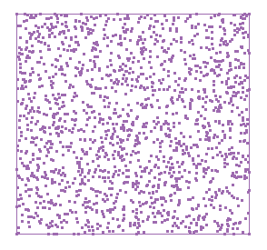

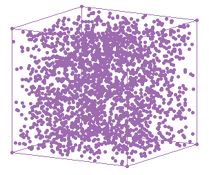

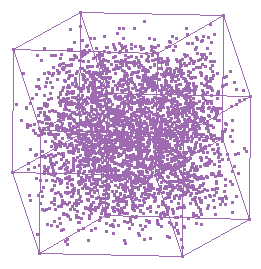

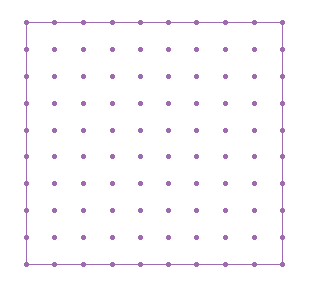

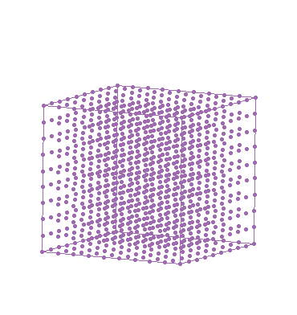

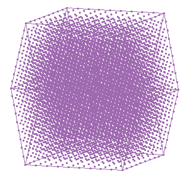

Figure 2: Solid cubes in 2-D, 3-D, and 4-D made of (top) independent random samples from *p* uniform distributions and (bottom) fixed grid points. As the dimensions increase, the vertices look sparse, more so with the random samples.

- **Method 1:** Random uniform.

  The R function `runif` generates samples from a uniform distribution between 0 and 1. Generating $p$ random uniform values creates a $p$-dimensional vector corresponding to a point inside a $p$-dimensional cube. The number of points needed to make the cube appear solid increases exponentially as $p$ increases. For example, a 3-D cube with $k$ points on each side has $k^3$ total points, and a 4-D cube with the same $k$ points per side $k^4$ total points. Thus, every time the dimension is increased, the number of points must be increased substantially for the shape to look similarly solid. In our `cube_solid_random` function, we use a base of 850 points, and the total number of points is capped at 50000 points for speed of viewing.

  ```r
  cube_solid_random <- function(p, n = 850 * 2 ^ p) {
    matrix(runif(n * p), ncol = p)
  }
  ```

- **Method 2:** Equidistant.

  A solid cube can be generated using equidistant points. As with the second vertex generation method, the `expand.grid` function is used. The input $n$ allows the number of grid points to be varied.

  ```r
  cube_solid_grid <- function(p, n) {
    grid <- list(seq(0, 1, length = n))
    do.call(expand.grid, rep(grid, p))
  }
  ```

There are advantages and disadvantages to the methods provided. The first method, random uniform points, produces a solid cube that looks more solid, but as $p$ increases, points near the vertices become more scarce. The second method, equidistant points, fills the vertex regions, but the structure produces regular patterns which can be distracting to the viewer.

### 2.4 Hollow cube

The “face” of a cube is a surface that is one dimension lower than that of the cube. For example, a face of a 3-D cube is a 2-D square and a face of a 4-D cube is a 3-D cube.

To generate points on the faces of a cube, points are created in all dimensions except one. The remaining dimension is given the value $0$ or $1$, to create the opposing faces. Because the face of a cube is a $(p-1)$-dimensional cube with a $0$ or $1$ in the remaining column, we may perform two different methods to produce the $p$-dimensional cube’s faces.

- **Method 1:** Equidistant faces.

  Equidistant faces may leverage the fact that each “face” contains the same data. Therefore, we may calculate a single $(p-1)$-dimensional equidistant cube and place it in the return matrix multiple times with the $i$th column missing from the return matrix. The number of rows of the return matrix is equivalent to $2 * p * nrow(face)$ with the first half of the return matrix being $0$’s and the last half being $1$’s. The input $n$ is supplied directly to the $cube\_solid\_grid$ function.

  ```r
  cube_face_grid <- function(p, n = 10) {
    face <- cube_solid_grid(p - 1, n)
    face_n <- nrow(face)
    faces <- do.call(data.frame, rep(list(X = rep(0:1, each = p * face_n)), p))
    for(i in seq_len(p)) {
      faces[(face_n * (i - 1) + 1):(face_n * i), -i] <- face
      faces[(face_n * (i - 1) + 1):(face_n * i) + (p * face_n), -i] <- face
    }
    return(as.matrix(faces))
  }
  ```

- **Method 2:** Random uniform faces.

  Naively creating a 3-D cube, the $X_1$ and $X_2$ components of the cube are given random values and the $X_3$ components would be set to $0$ in the first half and $1$ in the second half. The process would then be repeated for the remaining columns, as shown in Figure 3. This will create six 2-D squares which form the faces of a 3-D cube. The bottom row shows the different faces of a 4-D cube. The left side plot shows the first pair of faces, a solid 3-D cube in $X_1, X_2, X_3$, with fixed values on the fourth dimension $X_4$. The subsequent plots show the remaining faces.

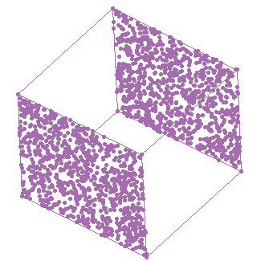

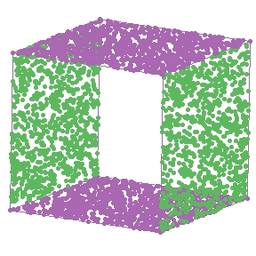

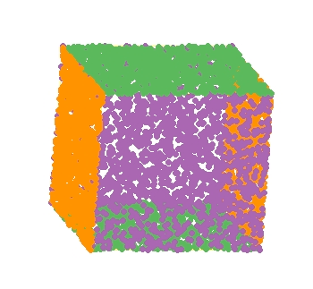

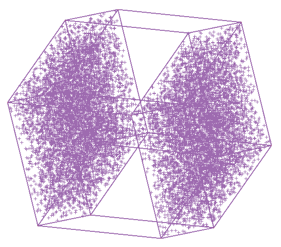

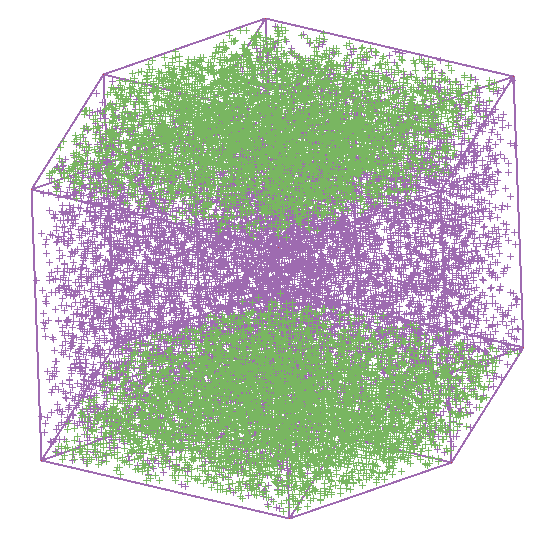

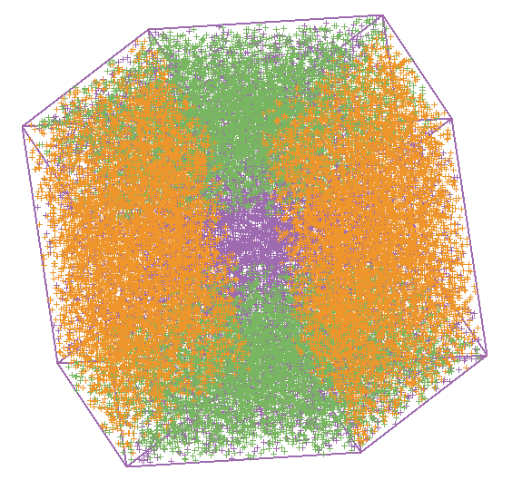

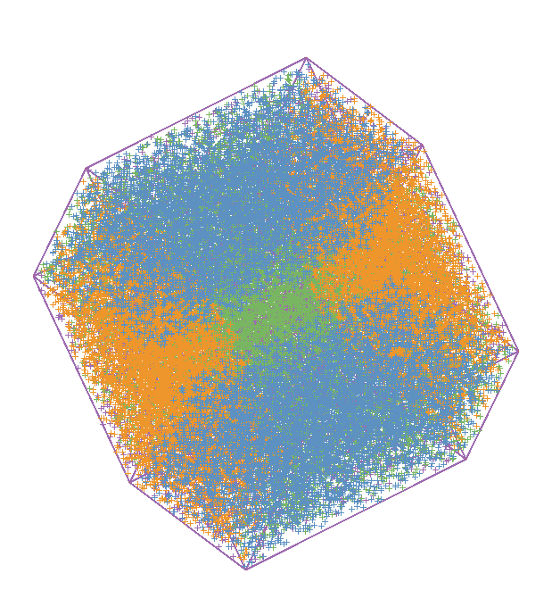

  Figure 3: Faces of a 3-D cube (top row) and a 4-D cube (bottom row), obtained by fixing one column of values to be 0 or 1, and allowing the other columns to vary freely between 0 and 1.

  Unlike the equidistant faces of a cube, each random uniform face must be different from every other face. To avoid repetitive calculations, we leverage the fact that a $p$-dimensional random uniform cube with one column missing is equivalent a $(p-1)$-dimensional random uniform cube. Therefore, we generate a $p$-dimensional cube and insert $0$’s or $1$’s for each of the corresponding faces in each dimension. The input $n$ matches the number of random points for a $(p-1)$-dimensional cube.

  ```r
  cube_face_random <- function(p, n = 850 * 2 ^ (p - 1)) {
    faces <- cube_solid_random(p, 2 * p * n)
    for (i in seq_len(p)) {
      faces[(n * (i - 1) + 1):(n * i), i] <- 0
      faces[(n * (i - 1) + 1):(n * i) + (p * face_n), i] <- 1
    }
    faces
  }
  ```

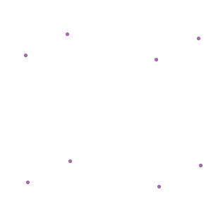

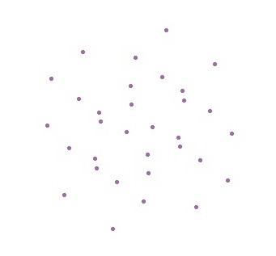

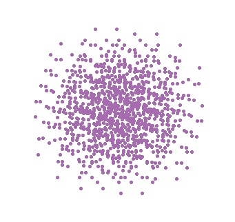

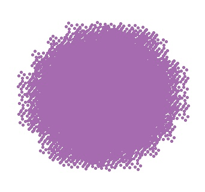

Figure 4: Vertices of cubes, (left to right) 3-D, 5-D, 10-D, and 15-D. Cubes look more rounded in projections as the dimension increases.

### 2.5 High-D cubes look spherical!

As the dimension increases, the shape of the cube appears more rounded than square in a 2-D projection. Explaination is given in Diaconis and Freedman (1984) and is related to the Central Limit Theorem. When we use a tour to visualize high-dimensional data we examine low-dimensional projections. Consider the axes for a $p$-dimensional space labeled as $X_1, ..., X_p$. A 1-D projection is generated by taking a linear combination of these axes, such as $a_1X_a+...+a_pX_p$. The squared values of $a_j, j=1, ..., p$ are constrained to sum to 1. As $p$ increases, combining the values operates like averaging the values in many dimensions, resulting in views that look Gaussian. Another way to think about it is that we are looking at rotated cubes rather than a cube through its square face and this gets increasingly rounded as the dimension increases.

## 3 Spheres

A sphere can be described as all points within a fixed radius (for simplicity use 1) around a fixed point (for simplicity use $\mathbf{zero}_p$), $\{X: X_1^2+\dots + X_p^2 \leq 1\}$. A hollow sphere is the set of points with radius equal to 1, $\{X: X_1^2+\dots + X_p^2 = 1\}$. Generating the hollow sphere is simpler than the solid sphere.

### 3.1 Hollow sphere

```r
norm_vec <- function(x) {
  x / sqrt(sum(x ^ 2))
}

sphere_hollow <- function(p, n = p * 500) {
  x <- matrix(rnorm(n * p), ncol = p)
  t(apply(x, 1, norm_vec))
}
```

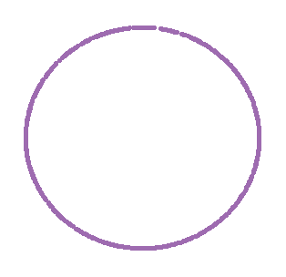

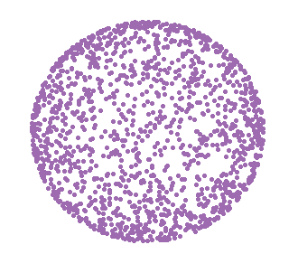

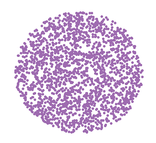

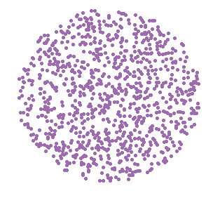

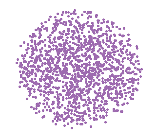

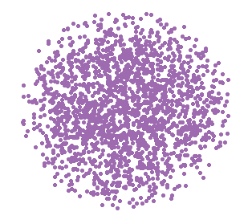

Figure 5: Hollow (top row) and solid spheres (bottom row) for 2-D, 3-D, 4-D.

### 3.2 Don’t reject the solid sphere!

Solid spheres can be generated in much the same way as solid cubes; use random points to fill the object. While the solid cube fills the box, the sphere’s points are inside a radius of 1 from the center. A simple approach would be to use a rejection method: generate points in the solid cube and discard those with radius more than 1. This is problematic as $p$ increases, since most points will eventually be rejected. For example, to generate the points of a 3-D sphere, around 50% of the proposed points are accepted, but for a 10-D sphere only 0.25% of the proposed points are accepted. The space in the corners of the enveloping cube, outside the sphere, increases dramatically with $p$.

```r
sphere_solid_random <- function(p, n = p * 500) {
  sphere_hollow(p, n) * runif(n) ^ (1 / p)
}
```

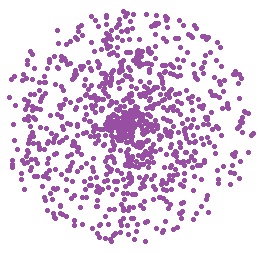

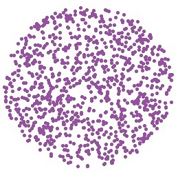

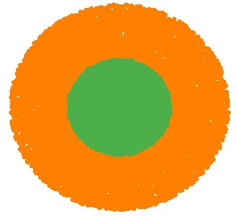

Figure 6: Solid sphere in 2-D: (left) generated randomly results in an over-concentration of points in the center, (middle) adjusted for volume generates a uniform distribution inside the sphere, and (right) comparison of areas of circles of radius 1 and 2.